# R Markdown Notes

Lawrence De Geest

*For a complete introduction see the [official RMarkdown page](https://rmarkdown.rstudio.com/lesson-1.html). Check out the [cheatsheet](https://rstudio.com/wp-content/uploads/2015/02/rmarkdown-cheatsheet.pdf) as well.*

# 1 Markdown

[Markdown](https://www.markdownguide.org/getting-started/) is a markup language. Formatting is coded and shown when the document is compiled.

To display code blocks, indent twice:

```
plot()
```

Quote with `>`:

> It was the best of times, it was the worst of times.

Wrap a word in one asterisks (`*`) to make it *italic*, two asterisks (`**`) to make it **bold**, three to make it *bold italics*.

Unordered lists:

- Item one
- Item two
- Item three

Ordered lists:

1. Item one
2. Item two
3. Item three

Hashtags (`#`) are used for headers, `##` for subheaders, `###` for subheaders, and so on.

## 1.1 Subheader

## 1.2 Subsubheader

# 2 Code chunks

R code can be placed in “chunks”:

```
{r}
```

Inside `{r}` you can add options like:

- `eval=F` so the code is printed but not evaluated;
- `echo=F` so the code is evaluated but not printed;
- a name for the chunk (e.g. `{r demo}`)
- and [more](https://yihui.name/knitr/options/?version=1.1.383&mode=desktop).

## 2.1 Figures

```
{r, barplot, fig.align="center", fig.width=6, fig.height=6, fig.cap="Figure caption."}
```

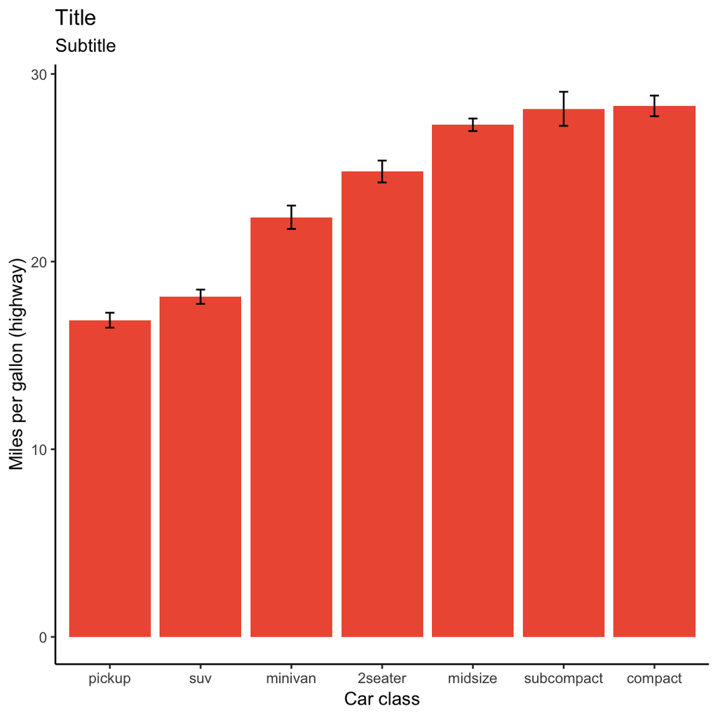

Figure caption.

```r
library(tidyverse)
mpg %>%
  ggplot(aes(reorder(class, hwy), hwy)) +
  stat_summary(fun.y = mean, geom = "bar", fill="tomato2") +
  stat_summary(fun.data = mean_se, geom = "errorbar", width=0.1) +
  labs(y="Miles per gallon (highway)", x="Car class", title="Title", subtitle = "Subtitle") +
  theme_classic()
```

## 2.2 Tables

There are lots of packages to [format tables](https://rmarkdown.rstudio.com/lesson-7.html). Personally I like [`library(kableExtra)`](http://haozhu233.github.io/kableExtra/awesome_table_in_html.html).

```r
library(kableExtra)
mpg %>%
  group_by(class) %>%
  summarise(avg_hwy = mean(hwy), avg_city = mean(cty)) %>%
  kable() %>% kable_styling(bootstrap_options = c("striped", "hover", "condensed", "responsive", full_width = F))
```

| class | avg_hwy | avg_city |
| --- | --- | --- |
| 2seater | 24.80000 | 15.40000 |
| compact | 28.29787 | 20.12766 |
| midsize | 27.29268 | 18.75610 |
| minivan | 22.36364 | 15.81818 |
| pickup | 16.87879 | 13.00000 |
| subcompact | 28.14286 | 20.37143 |
| suv | 18.12903 | 13.50000 |

Use [`library(stargazer)`](https://cran.r-project.org/web/packages/stargazer/index.html) for regression tables. All the options are in this [document](https://cran.r-project.org/web/packages/stargazer/stargazer.pdf). Here is a nice [cheatsheet](https://www.jakeruss.com/cheatsheets/stargazer/).

```r
library(stargazer)
m1 <- lm(hwy~class, data=mpg)
m2 <- lm(cty~class, data=mpg)
stargazer(m1,m2,
          type="html",
          style = "aer",
          omit.stat = c("adj.rsq", "f", "ser"),
          dep.var.labels.include = FALSE,
          column.labels = c("MPG (Highway)", "MPG (City)"),
          covariate.labels = c("Compact", "Midsize", "Minivan",
                               "Pickup", "Sub-compact", "SUV"),
          title = "Regression results",
          notes = "*Source*: Own calculations."
          )
```

**Regression results**

|  | MPG (Highway) | MPG (City) |
| --- | --- | --- |
|  | (1) | (2) |
| Compact | 3.498** | 4.728*** |
|  | (1.585) | (1.370) |
| Midsize | 2.493 | 3.356** |
|  | (1.596) | (1.380) |
| Minivan | -2.436 | 0.418 |
|  | (1.818) | (1.571) |
| Pickup | -7.921*** | -2.400* |
|  | (1.617) | (1.398) |
| Sub-compact | 3.343** | 4.971*** |
|  | (1.611) | (1.392) |
| SUV | -6.671*** | -1.900 |
|  | (1.567) | (1.354) |
| Constant | 24.800*** | 15.400*** |
|  | (1.507) | (1.302) |
| Observations | 234 | 234 |
| R<sup>2</sup> | 0.688 | 0.544 |
| *Notes:* | ***Significant at the 1 percent level. |  |
|  | **Significant at the 5 percent level. |  |
|  | *Significant at the 10 percent level. |  |
|  | *Source*: Own calculations. |  |

# 3 Math

Math is written with [LaTeX](https://en.wikibooks.org/wiki/LaTeX/Mathematics). Just like with HTML (e.g. `<p> ... </p>`) you wrap math code in “environments” (e.g. `\begin{equation} ... \end{equation}`.)

To write an inline equation, wrap it in `$`. `$y = \beta X$` produces $y=\beta X$.

To write an full-length equation, wrap it inside `\begin{equation} ... \end{equation}`:

```
\begin{equation}
y=\beta X + \varepsilon
\end{equation}
```

$$\begin{equation}
y=\beta X + \varepsilon
\end{equation}$$

To align equations use `aligned`:

```
\begin{aligned}
y &=\beta X + \varepsilon \\
  &= \beta_0 + \beta_1 x_1 + \beta_2 x_2 + \varepsilon
\end{aligned}
```

$$\begin{aligned}
y &=\beta X + \varepsilon \\
&= \beta_0 + \beta_1 x_1 + \beta_2 x_2 + \varepsilon
\end{aligned}$$

Use `\frac{}{}` to write fractions: `\frac{\partial f}{\partial x}` produces $\frac{\partial f}{\partial x}$